# DSCI 503 – Project 03

### Talaya Francois

```python
import numpy as np
import pandas as pd
import matplotlib.pyplot as plt
```

## Part 1: Loading the Dataset; Preliminary Analysis

Part 1 unpacks the diamond file, displays the first 10 rows, shows the size of the DataFrame, and presents a DataFrame with a statistical summary of the data.

```python
diamonds = pd.read_csv('diamonds.txt', sep='\t')
diamonds.head(10)
```

|  | carat | cut | color | clarity | depth | table | price | x | y | z |
| --- | --- | --- | --- | --- | --- | --- | --- | --- | --- | --- |
| 1 | 0.23 | Ideal | E | SI2 | 61.5 | 55.0 | 326 | 3.95 | 3.98 | 2.43 |
| 2 | 0.21 | Premium | E | SI1 | 59.8 | 61.0 | 326 | 3.89 | 3.84 | 2.31 |
| 3 | 0.23 | Good | E | VS1 | 56.9 | 65.0 | 327 | 4.05 | 4.07 | 2.31 |
| 4 | 0.29 | Premium | I | VS2 | 62.4 | 58.0 | 334 | 4.20 | 4.23 | 2.63 |
| 5 | 0.31 | Good | J | SI2 | 63.3 | 58.0 | 335 | 4.34 | 4.35 | 2.75 |
| 6 | 0.24 | Very Good | J | VVS2 | 62.8 | 57.0 | 336 | 3.94 | 3.96 | 2.48 |
| 7 | 0.24 | Very Good | I | VVS1 | 62.3 | 57.0 | 336 | 3.95 | 3.98 | 2.47 |
| 8 | 0.26 | Very Good | H | SI1 | 61.9 | 55.0 | 337 | 4.07 | 4.11 | 2.53 |
| 9 | 0.22 | Fair | E | VS2 | 65.1 | 61.0 | 337 | 3.87 | 3.78 | 2.49 |
| 10 | 0.23 | Very Good | H | VS1 | 59.4 | 61.0 | 338 | 4.00 | 4.05 | 2.39 |

In the next cell, we will determine the size of the dataset.

```python
print(diamonds.shape)
```

```
(53940, 10)
```

```python
diamonds.describe()
```

|  | carat | depth | table | price | x | y | z |
| --- | --- | --- | --- | --- | --- | --- | --- |
| count | 53940.000000 | 53940.000000 | 53940.000000 | 53940.000000 | 53940.000000 | 53940.000000 | 53940.000000 |
| mean | 0.797940 | 61.749405 | 57.457184 | 3932.799722 | 5.731157 | 5.734526 | 3.538734 |
| std | 0.474011 | 1.432621 | 2.234491 | 3989.439738 | 1.121761 | 1.142135 | 0.705699 |
| min | 0.200000 | 43.000000 | 43.000000 | 326.000000 | 0.000000 | 0.000000 | 0.000000 |
| 25% | 0.400000 | 61.000000 | 56.000000 | 950.000000 | 4.710000 | 4.720000 | 2.910000 |
| 50% | 0.700000 | 61.800000 | 57.000000 | 2401.000000 | 5.700000 | 5.710000 | 3.530000 |
| 75% | 1.040000 | 62.500000 | 59.000000 | 5324.250000 | 6.540000 | 6.540000 | 4.040000 |
| max | 5.010000 | 79.000000 | 95.000000 | 18823.000000 | 10.740000 | 58.900000 | 31.800000 |

## Part 2: Filtering and Sorting

We will start Part 2 by viewing information about the 5 most expensive diamonds in the dataset.

```python
diamonds.loc[:, ['price', 'carat', 'cut', 'color', 'clarity']]\
            .sort_values(by='price', ascending=False)\
            .head()
```

|  | price | carat | cut | color | clarity |
| --- | --- | --- | --- | --- | --- |
| 27750 | 18823 | 2.29 | Premium | I | VS2 |
| 27749 | 18818 | 2.00 | Very Good | G | SI1 |
| 27748 | 18806 | 1.51 | Ideal | G | IF |
| 27747 | 18804 | 2.07 | Ideal | G | SI2 |
| 27746 | 18803 | 2.00 | Very Good | H | SI1 |

We will now view information about the 5 least expensive diamonds in the dataset.

```python
diamonds.loc[:, ['price', 'carat', 'cut', 'color', 'clarity']]\
            .sort_values(by='price')\
            .head()
```

|  | price | carat | cut | color | clarity |
| --- | --- | --- | --- | --- | --- |
| 1 | 326 | 0.23 | Ideal | E | SI2 |
| 2 | 326 | 0.21 | Premium | E | SI1 |
| 3 | 327 | 0.23 | Good | E | VS1 |
| 4 | 334 | 0.29 | Premium | I | VS2 |
| 5 | 335 | 0.31 | Good | J | SI2 |

We will now view information about the 5 largest diamonds in the dataset with an ideal cut.

```python
diamonds.loc[:, ['price', 'carat', 'cut', 'color', 'clarity']]\
            .loc[diamonds['cut'] == 'Ideal']\
            .sort_values(by='carat', ascending=False)\
            .head()
```

|  | price | carat | cut | color | clarity |
| --- | --- | --- | --- | --- | --- |
| 24329 | 12587 | 3.50 | Ideal | H | I1 |
| 24298 | 12545 | 3.22 | Ideal | I | I1 |
| 26468 | 16037 | 3.01 | Ideal | J | SI2 |
| 26745 | 16538 | 3.01 | Ideal | J | I1 |
| 24785 | 13156 | 2.75 | Ideal | D | I1 |

We will now view information about the 5 largest diamonds in the dataset with an fair cut.

```python
diamonds.loc[:, ['price', 'carat', 'cut', 'color', 'clarity']]\
            .loc[diamonds['cut'] == 'Fair']\
            .sort_values(by='carat', ascending=False)\
            .head()
```

|  | price | carat | cut | color | clarity |
| --- | --- | --- | --- | --- | --- |
| 27416 | 18018 | 5.01 | Fair | J | I1 |
| 27631 | 18531 | 4.50 | Fair | J | I1 |
| 27131 | 17329 | 4.13 | Fair | H | I1 |
| 23645 | 11668 | 3.65 | Fair | H | I1 |
| 26432 | 15964 | 3.40 | Fair | D | I1 |

## Part 3: Working with Categorical Variable

In this part of the project, we will create lists to specify the order for each of the three categorical variables.

```python
clarity_levels = ['I1', 'SI2', 'SI1', 'VS2', 'VS1', 'VVS2', 'VVS1', 'IF']
cut_levels = ['Fair', 'Good', 'Very Good', 'Premium', 'Ideal']
color_levels = ['J', 'I', 'H', 'G', 'F', 'E', 'D' ]
```

```python
diamonds.loc[:, 'cut'] = pd.Categorical(diamonds['cut'], categories=cut_levels)
diamonds.loc[:, 'color'] = pd.Categorical(diamonds['color'], categories=color_levels)
diamonds.loc[:, 'clarity'] = pd.Categorical(diamonds['clarity'], categories=clarity_levels)
```

We will now create lists of named colors to serve as palettes to be used for visualizations later in the notebook.

```python
clarity_pal = ['brown', 'orange', 'deeppink', 'cyan', 'red', 'blue', 'yellow', 'lime']
cut_pal = ['cyan', 'darkcyan', 'forestgreen', 'lime', 'gold']
color_pal = ['slateblue', 'darkorchid','mediumvioletred', 'crimson','green', 'darkorange', 'gold']
```

## Part 4: Displaying Counts for Categorical Variables

We will start by counting the number of diamonds for each level of cut.

```python
diamonds.loc[:, 'cut']\
            .value_counts()\
            .sort_index()
```

```
cut
Fair          1610
Good          4906
Ideal        21551
Premium      13791
Very Good    12082
Name: count, dtype: int64
```

We will now count the number of diamonds for each level of color.

```python
diamonds.loc[:, 'color']\
            .value_counts()\
            .sort_index()
```

```
color
D     6775
E     9797
F     9542
G    11292
H     8304
I     5422
J     2808
Name: count, dtype: int64
```

We will now count the number of diamonds for each level of clarity.

```python
diamonds.loc[:, 'clarity']\
            .value_counts()\
            .sort_index()
```

```
clarity
I1        741
IF       1790
SI1     13065
SI2      9194
VS1      8171
VS2     12258
VVS1     3655
VVS2     5066
Name: count, dtype: int64
```

## Part 5: Scatterplots of Price Against Carat

In this part of the project, we will start by plotting all the diamond data in one scatterplot. Then we’ll color the points by clarity level and finally split them into separate subplots so each clarity gets its own visual for easy comparison.

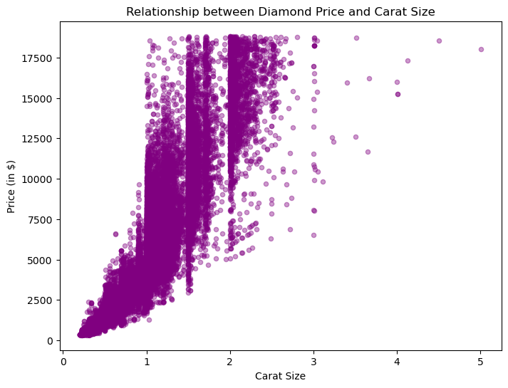

```python
y = diamonds.loc[:, 'price']
x = diamonds.loc[:, 'carat']

plt.figure(figsize=[8, 6])

plt.scatter(x, y, s=20 , c='purple', alpha=0.4)

plt.xlabel("Carat Size")  # X-axis label
plt.ylabel("Price (in $)")  # Y-axis label
plt.title("Relationship between Diamond Price and Carat Size")

plt.show()
```

Now we will reproduce the plot from above, but will now color the points according to their clarity.

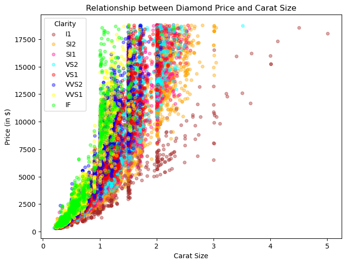

```python
plt.figure(figsize=[8, 6])

for i in range(len(clarity_levels)):
    clarity = clarity_levels[i]
    color = clarity_pal[i]

    x = diamonds.loc[diamonds.loc[:, 'clarity'] == clarity, 'carat']
    y = diamonds.loc[diamonds.loc[:, 'clarity'] == clarity, 'price']

    plt.scatter(x, y, s=20 , c=color, alpha=0.4, label=clarity)

plt.xlabel("Carat Size")
plt.ylabel("Price (in $)")
plt.title("Relationship between Diamond Price and Carat Size")

plt.legend(title="Clarity")
```

We will now separate the points for each of the eight clarity levels into its own subplot.

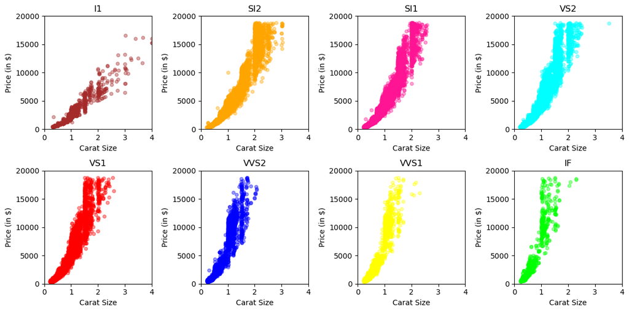

```python
plt.figure(figsize=(12, 6))

for i in range(8):
    plt.subplot(2, 4, i + 1)
    clarity = clarity_levels[i]
    color = clarity_pal[i]

    x = diamonds.loc[diamonds.loc[:, 'clarity'] == clarity, 'carat']
    y = diamonds.loc[diamonds.loc[:, 'clarity'] == clarity, 'price']

    plt.scatter(
        x,
        y,
        s=20,
        color=color,
        alpha=0.4,
    )
    plt.xlim([0, 4])
    plt.ylim([0, 20000])
    plt.title(clarity)
    plt.xlabel("Carat Size")
    plt.ylabel("Price (in $)")


plt.tight_layout()
plt.show()
```

# Part 6: Applying Logarithmic Transformations

We will start by adding two new columns to the diamonds in order to store the transformed variables.

```python
diamonds.loc[:, 'ln_carat'] = np.log(diamonds.loc[:, 'carat'])
diamonds.loc[:, 'ln_price'] = np.log(diamonds.loc[:, 'price'])
```

We will now use histograms to explore the distribution of the diamond prices, and the log of the diamond prices.

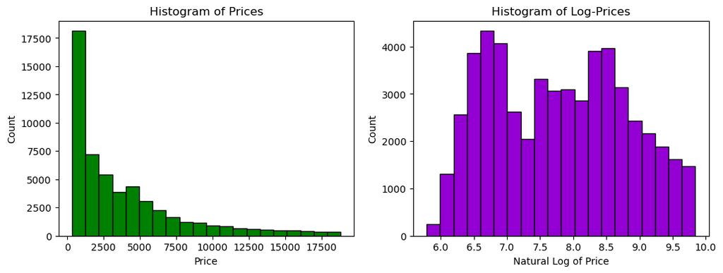

```python
plt.figure(figsize=[12, 4])

plt.subplot(1, 2, 1)
plt.hist(
    x=diamonds.loc[:, 'price'] ,
    bins=20,
    color='green',
    edgecolor='k',
)

plt.xlabel("Price")
plt.ylabel("Count")
plt.title("Histogram of Prices")

plt.subplot(1, 2, 2)

plt.hist(
    x=diamonds.loc[:, 'ln_price'],
    bins=20,
    color='darkviolet',
    edgecolor='k',
)

plt.xlabel("Natural Log of Price")
plt.ylabel("Count")
plt.title("Histogram of Log-Prices")

plt.show()
```

We will now use histograms to explore the distribution of the carat sizes, and the log of the carat sizes.

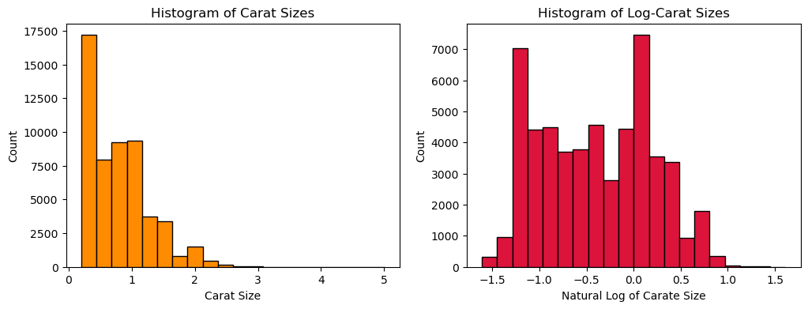

```python
plt.figure(figsize=[12, 4])

plt.subplot(1, 2, 1)
plt.hist(
    x=diamonds.loc[:, 'carat'] ,
    bins=20,
    color='darkorange',
    edgecolor='k',
)

plt.xlabel("Carat Size")
plt.ylabel("Count")
plt.title("Histogram of Carat Sizes")

plt.subplot(1, 2, 2)

plt.hist(
    x=diamonds.loc[:, 'ln_carat'],
    bins=20,
    color='crimson',
    edgecolor='k',
)

plt.xlabel("Natural Log of Carate Size")
plt.ylabel("Count")
plt.title("Histogram of Log-Carat Sizes")

plt.show()
```

## Part 7: Scatterplot of Transformed Variables

We will create a scatterplot of ln_price against ln_carat, with points colored according to their clarity.

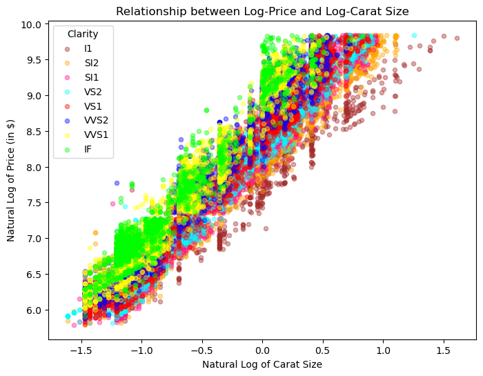

```python
plt.figure(figsize=[8, 6])

for i in range(len(clarity_levels)):
    clarity = clarity_levels[i]
    color = clarity_pal[i]

    x = diamonds.loc[diamonds.loc[:, 'clarity'] == clarity, 'ln_carat']
    y = diamonds.loc[diamonds.loc[:, 'clarity'] == clarity, 'ln_price']

    plt.scatter(x, y, s=20 , c=color, alpha=0.4, label=clarity)

plt.xlabel("Natural Log of Carat Size")
plt.ylabel("Natural Log of Price (in $)")
plt.title("Relationship between Log-Price and Log-Carat Size")

plt.legend(title="Clarity")
```

## Part 8: Grouping by Cut

We will create a grouped DataFrame displaying the mean price and carat size for each cut level.

```python
gb_cut = (diamonds.loc[:, ['cut', 'price', 'carat']]
          .groupby('cut')
          .mean()
         )
gb_cut
```

| cut | price | carat |
| --- | --- | --- |
| Fair | 4358.757764 | 1.046137 |
| Good | 3928.864452 | 0.849185 |
| Ideal | 3457.541970 | 0.702837 |
| Premium | 4584.257704 | 0.891955 |
| Very Good | 3981.759891 | 0.806381 |

We will now use bar charts to graphically display the information from the DataFrame above.

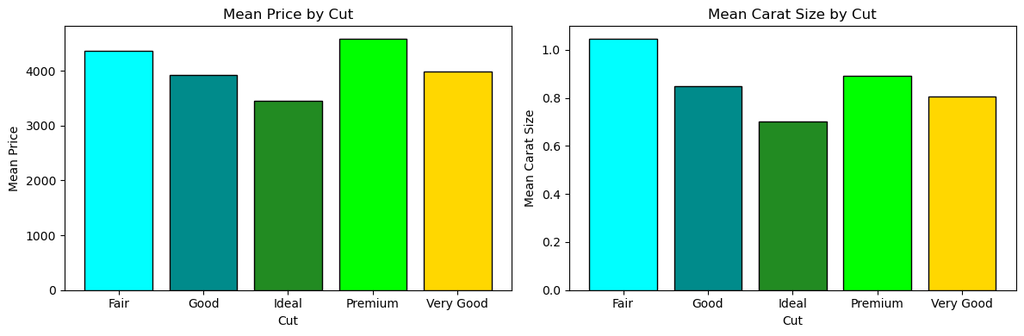

```python
x_labels = gb_cut.index
y_values1 = gb_cut.loc[:, 'price']
y_values2 = gb_cut.loc[:, 'carat']
plt.figure(figsize=(12, 4))

plt.subplot(1, 2, 1)
plt.bar(
    x_labels,
    y_values1,
    color=cut_pal,
    edgecolor='k',
)
plt.title('Mean Price by Cut')
plt.xlabel('Cut')
plt.ylabel('Mean Price')

plt.subplot(1, 2, 2)
plt.bar(
    x_labels,
    y_values2,
    color=cut_pal,
    edgecolor='k',
)
plt.title('Mean Carat Size by Cut')
plt.xlabel('Cut')
plt.ylabel('Mean Carat Size')

plt.tight_layout()
plt.show()
```

## Part 9: Grouping by Color

We will create a grouped DataFrame displaying the mean price and carat size for each color level.

```python
gb_color = (diamonds.loc[:, ['color', 'price', 'carat']]
          .groupby('color')
          .mean()
         )
gb_color
```

| color | price | carat |
| --- | --- | --- |
| D | 3169.954096 | 0.657795 |
| E | 3076.752475 | 0.657867 |
| F | 3724.886397 | 0.736538 |
| G | 3999.135671 | 0.771190 |
| H | 4486.669196 | 0.911799 |
| I | 5091.874954 | 1.026927 |
| J | 5323.818020 | 1.162137 |

We will now use bar charts to graphically display the information from the DataFrame above.

[figure not shown]

```python
x_labels = gb_color.index
y_values1 = gb_color.loc[:, 'price']
y_values2 = gb_color.loc[:, 'carat']
plt.figure(figsize=(12, 4))

plt.subplot(1, 2, 1)
plt.bar(
    x_labels,
    y_values1,
    color=color_pal,
    edgecolor='k',
)
plt.title('Mean Price by Cut')
plt.xlabel('Color')
plt.ylabel('Mean Price')

plt.subplot(1, 2, 2)
plt.bar(
    x_labels,
    y_values2,
    color=color_pal,
    edgecolor='k',
)
plt.title('Mean Carat Size by Cut')
plt.xlabel('Color')
plt.ylabel('Mean Carat Size')

plt.tight_layout()
plt.show()
```

## Part 10: Grouping by Clarity

We will create a grouped DataFrame displaying the mean price and carat size for each clarity level.

```python
gb_clarity = (diamonds.loc[:, ['clarity', 'price', 'carat']]
          .groupby('clarity')
          .mean()
         )
gb_clarity
```

| clarity | price | carat |
| --- | --- | --- |
| I1 | 3924.168691 | 1.283846 |
| IF | 2864.839106 | 0.505123 |
| SI1 | 3996.001148 | 0.850482 |
| SI2 | 5063.028606 | 1.077648 |
| VS1 | 3839.455391 | 0.727158 |
| VS2 | 3924.989395 | 0.763935 |
| VVS1 | 2523.114637 | 0.503321 |
| VVS2 | 3283.737071 | 0.596202 |

We will now use bar charts to graphically display the information from the DataFrame above.

[figure not shown]

```python
x_labels = gb_clarity.index
y_values1 = gb_clarity.loc[:, 'price']
y_values2 = gb_clarity.loc[:, 'carat']
plt.figure(figsize=(12, 4))

plt.subplot(1, 2, 1)
plt.bar(
    x_labels,
    y_values1,
    color=clarity_pal,
    edgecolor='k',
)
plt.title('Mean Price by Cut')
plt.xlabel('Clarity')
plt.ylabel('Mean Price')

plt.subplot(1, 2, 2)
plt.bar(
    x_labels,
    y_values2,
    color=clarity_pal,
    edgecolor='k',
)
plt.title('Mean Carat Size by Cut')
plt.xlabel('Clarity')
plt.ylabel('Mean Carat Size')

plt.tight_layout()
plt.show()
```